# 9041 Lab Assignment 6

Count Data Regression

Author

Katelyn Helka

Published

November 25, 2026

# Lab Set-Up

```r
library(tidyverse)
library(psych)
library(ordinal)
library(readxl)
library(ggeffects)
library(broom)
library(gt)
```

### Load and inspect the data

```
# A tibble: 6 × 29
   ...1    A1    A2    A3    A4    A5    C1    C2    C3    C4    C5    E1    E2
  <dbl> <int> <int> <int> <int> <int> <int> <int> <int> <int> <int> <int> <int>
1 61617     2     4     3     4     4     2     3     3     4     4     3     3
2 61618     2     4     5     2     5     5     4     4     3     4     1     1
3 61620     5     4     5     4     4     4     5     4     2     5     2     4
4 61621     4     4     6     5     5     4     4     3     5     5     5     3
5 61622     2     3     3     4     5     4     4     5     3     2     2     2
6 61623     6     6     5     6     5     6     6     6     1     3     2     1
# ℹ 16 more variables: E3 <int>, E4 <int>, E5 <int>, N1 <int>, N2 <int>,
#   N3 <int>, N4 <int>, N5 <int>, O1 <int>, O2 <int>, O3 <int>, O4 <int>,
#   O5 <int>, gender <dbl>, education <chr>, age <dbl>
```

### Question and Predictions

The `bfi` data contain 25 personality items from 2,800 people, five items per Big Five trait. Each item is answered on a 6-point scale from *Very inaccurate* to *Very accurate*.

If a person is more open, they will most likely be able to talk with a variety of people about a wide array of topics which will translate into making friends easily. Therefore, I predict that when people are more open, they will be more likely to make friends easily.

### Data preparation

```r
# Labels for the six response options, from lowest to highest
n_levels <- c("Very inaccurate", "Moderately inaccurate", "Slightly inaccurate",
              "Slightly accurate", "Moderately accurate", "Very accurate")

# Scoring keys with reverse-keyed items
keys <- list(
  Agreeableness     = c("-A1", "A2", "A3", "A4", "A5"),
  Conscientiousness = c("C1", "C2", "C3", "-C4", "-C5"),
  Extraversion      = c("-E1", "-E2", "E3", "E4", "E5"),
  Neuroticism       = c("N1", "N2", "N3", "N4", "N5"),
  Openness          = c("O1", "-O2", "O3", "O4", "-O5")
)

scores<-scoreItems(keys, data, totals = F, min=1, max=6)

scores_df<- scores$scores

# Mutate data to include the ordered outcome, an unordered outcome, and the predictor (raw and centred)
data <- data |>
  select(E4) |>
  bind_cols(as_tibble(scores_df)) |>
  mutate(
    E4 = factor(E4, levels = 1:6, labels = n_levels, ordered = TRUE),   # The ordered outcome
    highest = factor(names(keys)[max.col(scores_df, ties.method = "first")]),  # Unordered outcome:highest-scoring trait
    open = Openness
  ) |>
  drop_na(E4, open, highest) |>
  mutate(open_c = open - mean(open))  # Centre AFTER dropping missing cases

open_bar <- mean(data$open)
```

# Examining the Outcomes

### The ordered outcome

```r
# Count how many people chose each response option for E4.
e4_counts <- data |>
  count(E4) |>
  # p is the proportion of the sample in each category, P(Y = j).
  mutate(p = n / sum(n))
```

```r
e4_counts |>
   mutate(p = round(p, digits = 3)) |>
  gt()
```

| E4 | n | p |
| --- | --- | --- |
| Very inaccurate | 140 | 0.050 |
| Moderately inaccurate | 262 | 0.094 |
| Slightly inaccurate | 271 | 0.097 |
| Slightly accurate | 450 | 0.161 |
| Moderately accurate | 942 | 0.338 |
| Very accurate | 726 | 0.260 |

Every category has plenty of responses (the smallest, *Very inaccurate*, has 140), so each threshold can be estimated without collapsing categories.

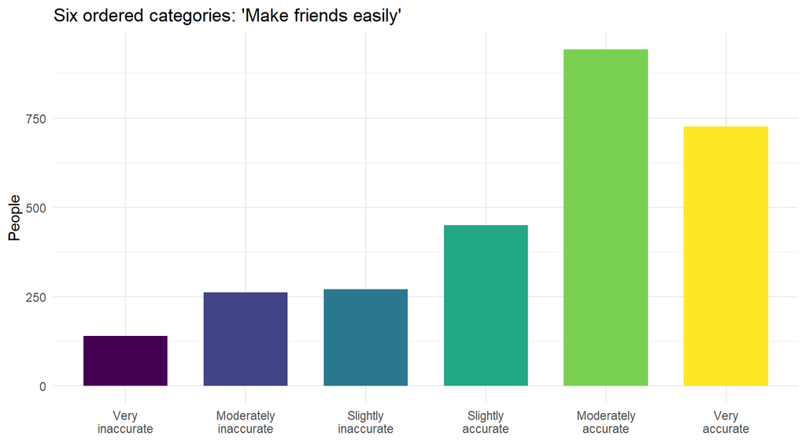

```r
#plot the counts
plot_e4 <- ggplot(e4_counts, aes(x = E4, y = n, fill = E4)) +
  geom_col(width = 0.7) +
  scale_x_discrete(labels = scales::label_wrap(12)) +
  labs(title = "Six ordered categories: 'Make friends easily'",
       x = NULL, y = "People") +
  theme_minimal() +
  theme(legend.position = "none")

plot_e4
```

### Showing How the Predictor Relates to the Outcome

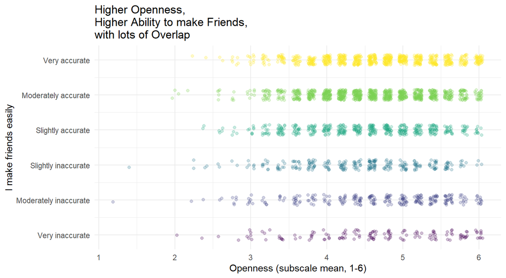

```r
plot_jitter<-ggplot(data, aes(open, as.numeric(E4), colour = E4)) +
  geom_jitter(width = 0.05, height = 0.15, alpha = 0.25, size = 1.4) +
  scale_y_continuous(breaks = 1:6, labels = n_levels) +
  labs(title = "Higher Openness,\nHigher Ability to make Friends,\nwith lots of Overlap",
       x = "Openness (subscale mean, 1-6)", y = "I make friends easily") +
  theme_minimal() +
  theme(legend.position = "none")

plot_jitter
```

The jitter plot shows a positive association between Openness and the tendency to endorse the item `I make friends easily` as higher Openness scores appear to have larger clusters along the item. However there is a lot of overlap along Openness scores and each level of agreement with the item. This makes sense as the outcome is ordinal, so although the response categories have a meaningful order, the distances between response options cannot be assumed equal. Therefore, an appropriate model should estimate the probability of an individual responding in each category rather than predicting a single numerical value especially since a predicted numeric value does not correspond to an actual response category.

### The Unordered Outcome

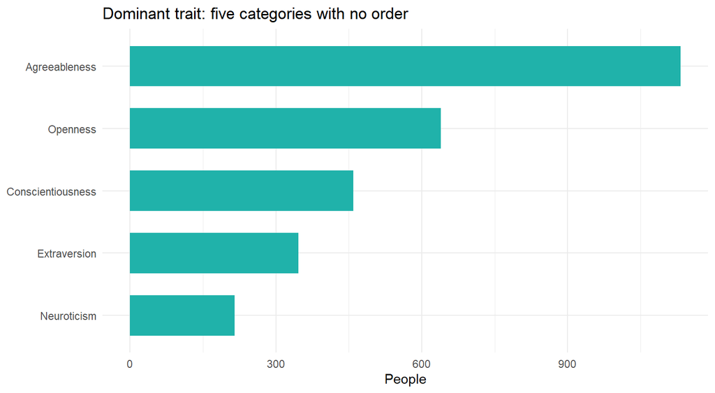

```r
ordered_dat <- data |>
  count(highest) |>
  mutate(highest = fct_reorder(highest, n))

#plot the unordered outcome
unordered_plot <- ggplot(ordered_dat, aes(highest, n)) +
  geom_col(width = 0.65, fill = "lightseagreen") +
  coord_flip() +
  labs(title = "Dominant trait: five categories with no order",
       x = NULL, y = "People") +
  theme_minimal()

unordered_plot
```

Since each person’s **dominant trait** (their highest of the five subscale scores) is a set of categories with **no built-in order** and therefore `highest` is an unordered variable. For example, scoring highest on Openness is not “more” than scoring highest on Agreeableness, or vice versa.

# Cumulative Probabilities

### Cumulative Proportion Table

```r
#creating the table
obs_tab <- data |>
  count(E4) |>
  mutate(
    Probability = n / sum(n),
    CumulativeProbability = cumsum(Probability),
    CumulativeOdds = if_else(CumulativeProbability < 1,
                             CumulativeProbability / (1 - CumulativeProbability), NA_real_),
    Cumulative_Logodds = if_else(CumulativeProbability < 1,
                                 qlogis(CumulativeProbability), NA_real_)
  )

# creating a clean table with gt
obs_tab |>
  gt() |>
  cols_label(
    E4 = "Category in E4 (j)",
    n = "n",
    Probability = "P(Y = j)",
    CumulativeProbability = "P(Y ≤ j)",
    CumulativeOdds = "Odds of ≤ j",
    Cumulative_Logodds = "Log-odds of ≤ j"
  ) |>
  fmt_number(columns = c(Probability, CumulativeProbability), decimals = 3) |>
  fmt_number(columns = c(CumulativeOdds, Cumulative_Logodds), decimals = 3) |>
  sub_missing(missing_text = "—")
```

| Category in E4 (j) | n | P(Y = j) | P(Y ≤ j) | Odds of ≤ j | Log-odds of ≤ j |
| --- | --- | --- | --- | --- | --- |
| Very inaccurate | 140 | 0.050 | 0.050 | 0.053 | −2.941 |
| Moderately inaccurate | 262 | 0.094 | 0.144 | 0.168 | −1.782 |
| Slightly inaccurate | 271 | 0.097 | 0.241 | 0.318 | −1.146 |
| Slightly accurate | 450 | 0.161 | 0.402 | 0.673 | −0.396 |
| Moderately accurate | 942 | 0.338 | 0.740 | 2.844 | 1.045 |
| Very accurate | 726 | 0.260 | 1.000 | — | — |

Please note that since a cumulative probability is the probability of responding **with a specific response category (*j*)** or lower, each category’s probability will increase as the probability of that response is added to the probabilities of each lower response (i.e., selecting slightly inaccurate OR moderately inaccurate OR very inaccurate). Therefore, with six categories there are five cumulative probabilities to model as the cumulative probability of the sixth category (very accurate) is 100%. This is also why the odds for any last category in cumulative probabilities has undefined odds; all categories are included in the final category so there is not a binary outcome for an odds formula to calculate the probability of not choosing any option.

# Specifying and Estimating Cumulative logit Models

As I stated above, the outcome `E4 - makes friends easily` is ordinal - the response categories have a meaningful order (*Very inaccurate < Moderately inaccurate < Slightly inaccurate < Slightly accurate < Moderately accurate < Very accurate*) but the distances between response options cannot be assumed equal as people may interpret the response categories differently. Therefore, an appropriate model should estimate the probability of an individual responding in each ordered category which is why an ordinal model suits this response outcome.

### Estimating the Two Nested Models

```r
# Null model: thresholds only, no predictors
null <- clm(E4 ~ 1, data = data)

# One-predictor model
one_pred <- clm(E4 ~ open_c, data = data)

summary(one_pred)
```

```
formula: E4 ~ open_c
data:    data

 link  threshold nobs logLik   AIC     niter max.grad cond.H
 logit flexible  2791 -4488.88 8989.77 5(0)  1.19e-12 2.4e+01

Coefficients:
       Estimate Std. Error z value Pr(>|z|)
open_c  0.11977    0.04291   2.791  0.00525 **
---
Signif. codes:  0 '***' 0.001 '**' 0.01 '*' 0.05 '.' 0.1 ' ' 1

Threshold coefficients:
                                          Estimate Std. Error z value
Very inaccurate|Moderately inaccurate     -2.94621    0.08677  -33.95
Moderately inaccurate|Slightly inaccurate -1.78814    0.05400  -33.12
Slightly inaccurate|Slightly accurate     -1.15235    0.04435  -25.98
Slightly accurate|Moderately accurate     -0.39965    0.03867  -10.34
Moderately accurate|Very accurate          1.04593    0.04318   24.22
```

I **centred** Openness earlier, so that the thresholds describe a person of average Openness (4.593), rather than an impossible person scoring 0 on a 1-6 scale. Centring changes the thresholds but **not** the slope since the change in values will remain the same.

The estimated slope is beta = 0.12, so Higher Openness **lowers** the log-odds of being at or below each threshold, which shifts responses toward the **higher** (“accurate”) categories.

### What the centred thresholds mean

```r
# plogis() turns a log-odds into a probability.

tibble(
  Category = n_levels,
  theta = c(th, NA),
  cum = c(plogis(th), 1),
  cat_p = diff(c(0, plogis(th), 1))
) |>
  gt() |>
  cols_label(
    theta = "Threshold above category",
    cum = "P(Y ≤ j)",
    cat_p = "P(Y = j)"
  ) |>
  fmt_number(columns = theta, decimals = 2) |>
  fmt_number(columns = c(cum, cat_p), decimals = 2) |>
  sub_missing(missing_text = "—")
```

| Category | Threshold above category | P(Y ≤ j) | P(Y = j) |
| --- | --- | --- | --- |
| Very inaccurate | −2.95 | 0.05 | 0.05 |
| Moderately inaccurate | −1.79 | 0.14 | 0.09 |
| Slightly inaccurate | −1.15 | 0.24 | 0.10 |
| Slightly accurate | −0.40 | 0.40 | 0.16 |
| Moderately accurate | 1.05 | 0.74 | 0.34 |
| Very accurate | — | 1.00 | 0.26 |

### Checking the Null Model

```r
#|label: check null

# View thresholds produced, and how they are the same as the cumulative log-odds
coef(null)
```

```
    Very inaccurate|Moderately inaccurate
                               -2.9410498
Moderately inaccurate|Slightly inaccurate
                               -1.7821781
    Slightly inaccurate|Slightly accurate
                               -1.1464822
    Slightly accurate|Moderately accurate
                               -0.3956216
        Moderately accurate|Very accurate
                                1.0453355
```

```r
obs_tab$Cumulative_Logodds[1:5]
```

```
[1] -2.9410498 -1.7821781 -1.1464822 -0.3956216  1.0453355
```

As can be seen with the above output, the null model has the same thresholds as the observed cumulative log-odds. This is because in a null model without any predictors, the thresholds are estimated using the cumulative log-odds from the data. The one-pred model uses Openness as a predictor, so the thresholds are now estimated using the differences in Openness. Therefore, since the predictor is included in the model, the probability of selecting different response categories is reliant on the predictor.

# Comparing the Models

```r
#|label: comparing the models

# anova() on two clm models gives an LRT
lrt <- anova(null, one_pred)
lrt
```

```
Likelihood ratio tests of cumulative link models:

         formula:    link: threshold:
null     E4 ~ 1      logit flexible
one_pred E4 ~ open_c logit flexible

         no.par    AIC  logLik LR.stat df Pr(>Chisq)
null          5 8995.5 -4492.8
one_pred      6 8989.8 -4488.9  7.7777  1   0.005289 **
---
Signif. codes:  0 '***' 0.001 '**' 0.01 '*' 0.05 '.' 0.1 ' ' 1
```

Adding Openness improves fit by a statistically significant amount, χ²(1) = 7.78, *p* = 0.005. The change in the degree of freedom is because the Openness model estimates one additional parameter, the Openness predictor and the χ² value and p-value shows us that including Openness signficiantly improved the fit of the model.

```r
# logLik() and AIC() pull the fit statistics from each model.
# length(coef(...)) counts the estimated parameters.
tibble(
  Model = c("Null", "Openness"),
  Parameters = c(length(coef(null)), length(coef(one_pred))),
  logLik = c(logLik(null), logLik(one_pred)),
  AIC = c(AIC(null), AIC(one_pred))
) |>
  mutate(`ΔAIC` = AIC - min(AIC)) |>
  gt() |>
  fmt_number(columns = c(logLik, AIC, `ΔAIC`), decimals = 1)
```

| Model | Parameters | logLik | AIC | ΔAIC |
| --- | --- | --- | --- | --- |
| Null | 5 | −4,492.8 | 8,995.5 | 5.8 |
| Openness | 6 | −4,488.9 | 8,989.8 | 0.0 |

AIC agrees with the likelihood ratio test: the Openness model is preferred by a small margin (ΔAIC = 5.8).Therefore, I am choosing the Openness model (`one_pred`) as it improved model fit significantly (χ²(1) = 7.78, *p* = 0.005).

### Interpretting the Slope on the Latent Scale

```r
lr_stat <- lrt$LR.stat[2]
lr_df <- lrt$df[2]
lr_p <- lrt$`Pr(>Chisq)`[2]
d_aic <- AIC(null) - AIC(one_pred)
```

The slope, beta = 0.1197721, is on the latent logit scale. A one-point increase in Openness moves a person’s latent “extraversion proneness” as reflected by E4 up by 0.1197721. The middle categories are each about 0.6942459 units wide on that scale, so one point of Openness shifts someone by roughly 17.2521133% of a category.

# Check the Proportional Odds Assumption

### Testing Proportional Odds

```r
nt <- nominal_test(one_pred)
nt
```

```
Tests of nominal effects

formula: E4 ~ open_c
       Df  logLik    AIC    LRT  Pr(>Chi)
<none>    -4488.9 8989.8
open_c  4 -4478.8 8977.7 20.073 0.0004831 ***
---
Signif. codes:  0 '***' 0.001 '**' 0.01 '*' 0.05 '.' 0.1 ' ' 1
```

The nominal test **was** significant (χ²(4) = 20.07, *p* < .001). and so I will also use a partial proportional-odds model as seen below.

### Fitting a Partial Proportional Odds Model

```r
#partial odds model
m_nom <- clm(E4 ~ 1, nominal = ~ open_c, data = data)

#compare the two models to see which has superior fit

anova(one_pred, m_nom)
```

```
Likelihood ratio tests of cumulative link models:

         formula:    nominal: link: threshold:
one_pred E4 ~ open_c ~1       logit flexible
m_nom    E4 ~ 1      ~open_c  logit flexible

         no.par    AIC  logLik LR.stat df Pr(>Chisq)
one_pred      6 8989.8 -4488.9
m_nom        10 8977.7 -4478.8  20.073  4  0.0004831 ***
---
Signif. codes:  0 '***' 0.001 '**' 0.01 '*' 0.05 '.' 0.1 ' ' 1
```

```r
# Look at the estimates: the first 5 are the thresholds, and estimates 6 to 10 are the five Openness slopes (one per threshold).

coef(m_nom)
```

```
    Very inaccurate|Moderately inaccurate.(Intercept)
                                          -2.94397536
Moderately inaccurate|Slightly inaccurate.(Intercept)
                                          -1.78528969
    Slightly inaccurate|Slightly accurate.(Intercept)
                                          -1.14707317
    Slightly accurate|Moderately accurate.(Intercept)
                                          -0.39680010
        Moderately accurate|Very accurate.(Intercept)
                                           1.05142441
         Very inaccurate|Moderately inaccurate.open_c
                                           0.09187796
     Moderately inaccurate|Slightly inaccurate.open_c
                                           0.10763330
         Slightly inaccurate|Slightly accurate.open_c
                                          -0.05269022
         Slightly accurate|Moderately accurate.open_c
                                          -0.14055307
             Moderately accurate|Very accurate.open_c
                                          -0.20709227
```

```r
nom_est <- coef(m_nom)[6:10]

# Their standard errors. vcov() gives the variance-covariance matrix of the estimates; diag() takes its diagonal (the variances), and sqrt() turns variances into standard errors.

nom_se <- sqrt(diag(vcov(m_nom)))[6:10]

threshold_or <- tibble(
  Threshold = c("Very inaccurate | Moderately inaccurate",
                "Moderately inaccurate | Slightly inaccurate",
                "Slightly inaccurate | Slightly accurate",
                "Slightly accurate | Moderately accurate",
                "Moderately accurate | Very accurate"),
  Estimate = nom_est,
  SE = nom_se,
  OR = exp(-Estimate),
  low = exp(-(Estimate + 1.96 * SE)),
  high = exp(-(Estimate - 1.96 * SE))
)

threshold_or |>
  gt() |>
  fmt_number(
    columns = where(is.numeric),
    decimals = 2
  )
```

| Threshold | Estimate | SE | OR | low | high |
| --- | --- | --- | --- | --- | --- |
| Very inaccurate \| Moderately inaccurate | 0.09 | 0.10 | 0.91 | 0.75 | 1.11 |
| Moderately inaccurate \| Slightly inaccurate | 0.11 | 0.07 | 0.90 | 0.79 | 1.02 |
| Slightly inaccurate \| Slightly accurate | −0.05 | 0.06 | 1.05 | 0.95 | 1.18 |
| Slightly accurate \| Moderately accurate | −0.14 | 0.05 | 1.15 | 1.04 | 1.27 |
| Moderately accurate \| Very accurate | −0.21 | 0.06 | 1.23 | 1.10 | 1.38 |

These results further demonstrate that the `one_pred` model violated the proportional odds assumption. The likelihood ratio test indicated that allowing th effect of Openness to vary across response threshold (the nominal model `m_nom`) significantly improved model fit (χ²(4) = 20, *p* < .001).

# Interpreting the Results

### Interpreting the Odds Ratio

```r
or_tab <- tidy(one_pred, conf.int = TRUE, conf.type = "Wald", exponentiate = TRUE) |>
   filter(coef.type == "location")

or_tab |>
  gt() |>
  fmt_number(
    columns = where(is.numeric),
    decimals = 3
  )
```

| term | estimate | std.error | statistic | p.value | conf.low | conf.high | coef.type |
| --- | --- | --- | --- | --- | --- | --- | --- |
| open_c | 1.127 | 0.043 | 2.791 | 0.005 | 1.036 | 1.226 | location |

```r
# We use the threshold between "Slightly inaccurate" and "Slightly accurate", because the model used centred Openness, I'll subtract open_bar from each raw score first.

# The model gives log-odds of being AT OR BELOW the threshold:
#     log-odds = threshold - slope * open_c

# Openness = 3
logodds_3 <- nom_est[3] - b * (3 - open_bar)   # log-odds of at or below
prob_3    <- 1 - plogis(logodds_3)         # plogis() -> probability; 1 - it = P(above)
odds_3    <- prob_3 / (1 - prob_3)         # odds of being above

# Openness = 4
logodds_4 <- nom_est[3] - b * (4 - open_bar)
prob_4    <- 1 - plogis(logodds_4)
odds_4    <- prob_4 / (1 - prob_4)

# Openness = 5
logodds_5 <- nom_est[3] - b * (5 - open_bar)
prob_5    <- 1 - plogis(logodds_5)
odds_5    <- prob_5 / (1 - prob_5)

# Openness = 6
logodds_6 <- nom_est[3] - b * (6 - open_bar)
prob_6    <- 1 - plogis(logodds_6)
odds_6    <- prob_6 / (1 - prob_6)

prob_tab <- tibble(
  Openness = c(3, 4, 5, 6),
  Prob = c(prob_3, prob_4, prob_5, prob_6),
  Odds = c(odds_3, odds_4, odds_5, odds_6)
)

prob_tab |>
  gt() |>
  cols_label(Prob = "P(Slightly accurate or higher)") |>
  fmt_number(columns = c(Prob, Odds), decimals = 2)
```

| Openness | P(Slightly accurate or higher) | Odds |
| --- | --- | --- |
| 3 | 0.47 | 0.87 |
| 4 | 0.50 | 0.98 |
| 5 | 0.53 | 1.11 |
| 6 | 0.56 | 1.25 |

### Plotting Predicted Category Probabilities

```r
# ggpredict() returns one row per Openness value x response category.
pred <- ggpredict(m_nom, terms = "open_c [all]")
```

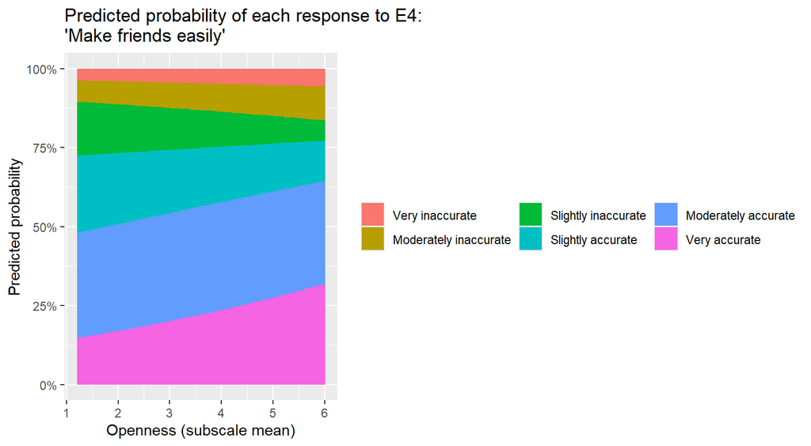

```r
pred |>
  as.data.frame() |>
  mutate(
    response.level = factor(response.level,
                            labels = n_levels),
    open = x + open_bar
  ) |>
  ggplot(aes(open, predicted, fill = response.level)) +
  geom_area(position = "stack") +
  scale_y_continuous(labels = scales::percent) +
  guides(fill = guide_legend(nrow = 2)) +
  labs(title = "Predicted probability of each response to E4:\n'Make friends easily'",
       x = "Openness (subscale mean)",
       y = "Predicted probability", fill = NULL)
```

At all levels of Openness the probability mostly sits in the “accurate” categories but at *low* Openness, more of the probability sits in the “inaccurate” categories than at *high* Openness. As Openness rises, it moves more toward *Moderately accurate* and *Very accurate*. At every value of Openness, the six probabilities sum to 1, which is why the stack always reaches 100%.

### Coefficient Plot of Cumulative Odds Ratios

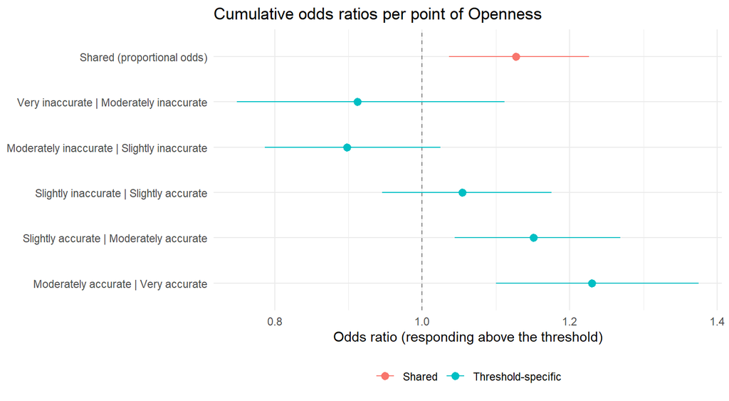

```r
bind_rows(
  tibble(Threshold = "Shared (proportional odds)", OR = or_tab$estimate,
         low = or_tab$conf.low, high = or_tab$conf.high, type = "Shared"),
  threshold_or |> transmute(Threshold, OR, low, high, type = "Threshold-specific")
) |>
  mutate(Threshold = fct_rev(fct_inorder(Threshold))) |>   # keep thresholds in order, top to bottom
  ggplot(aes(OR, Threshold, colour = type)) +
  geom_vline(xintercept = 1, linetype = "dashed", colour = "grey50") +  # OR = 1 means no effect
  geom_pointrange(aes(xmin = low, xmax = high)) +
  labs(title = "Cumulative odds ratios per point of Openness",
       x = "Odds ratio (responding above the threshold)", y = NULL, colour = NULL) +
  theme_minimal() +
  theme(legend.position = "bottom")
```

None of the intervals sit well below 1 (the dashed line), and two intervals sit well above 1. The threshold-specific estimates also vary in size across the response categories, rather than consistently matching the shared odds ratio from the proportional-odds model. This suggests that the effect of Openness differs depending on the threshold which provides further evidence that the proportional-odds assumption was violated and the partial proportional-odds model was more appropriate.

# 8. Results paragraph

The threshold-specific odds ratios showed that the association between Openness and response endorsement varied across the response scale (Figure: Cumulative odds ratios per point of Openness). At the two lowest thresholds, the odds ratios were 0.91 (95% CI [0.75, 1.11]) and 0.9 (95% CI [0.79, 1.02]), respectively, with both confidence intervals including 1. The association became stronger at the higher thresholds, with odds ratios of 1.15 (95% CI [1.04, 1.27]) and 1.23 (95% CI [1.1, 1.38]). Both of these confidence intervals were above 1. This suggests that Openness was more strongly associated with endorsing the higher response categories, supporting the use of the partial proportional-odds model.

Overall, my prediction was supported.